# Heart Attack Analysis & Prediction Using R

by Gift Mtambo

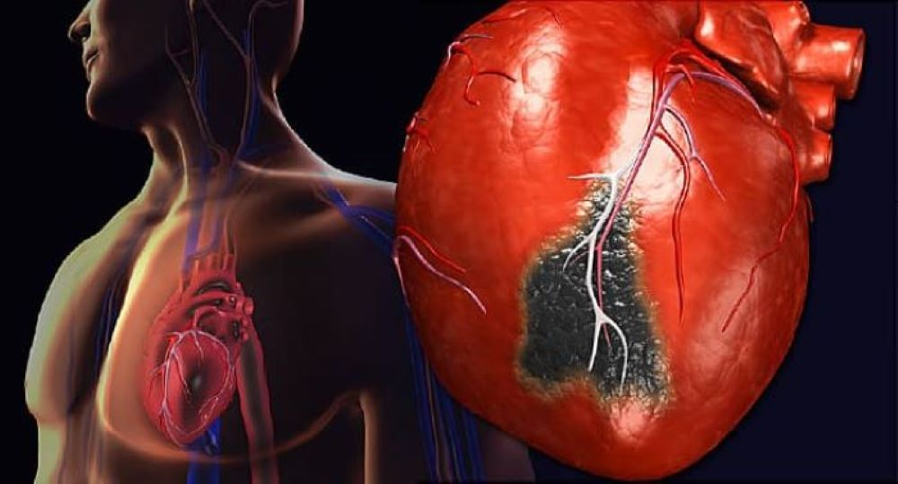

### 1.0.INTRODUCTION

- A heart attack occurs when the flow of blood to the heart is blocked. The blockage is most often a buildup of fat, cholesterol and other substances, which form a plaque in the arteries that feed the heart (coronary arteries).
- Sometimes, a plaque can rupture and form a clot that blocks blood flow.The interrupted blood flow can damage or destroy part of the heart muscle.

### Objectives:

- Analyse the datasets to determine which machine learning model is accurate.
- Classify whether someone has less chances or more chances of heart attack
- To determine which features are the most indicative of of heart attack

### Dataset Information:

- The dataset can be downloaded using this [link](https://www.kaggle.com/rashikrahmanpritom/heart-attack-analysis-prediction-dataset).
- The Dataset consist of 14 columns of which are both numerical and categorical variables and one of them is a Output variable-which consist of 1 or 0 indicating whether a person has a more chance of heart attack(1) or less chance of heart attack(0).

**The characteristics variables includes the following**

### 2.Loading and Checking the dataset:

```r
#Load the packages
library(dplyr)
library(ggplot2)
library(tidyr)
library(psych)
library(psychTools)
library(tidyverse)
library(hrbrthemes)
library(randomForest)
library(forcats)
library(corrplot)
library(GGally)
library(viridis)
library(corrr)
library(DataExplorer)
library(caret)
library(caTools)
library(e1071)
library(class)
library(pROC)
```

#### load the dataset

```r
# define the filename
filename <- "heart.csv"
# load the CSV file from the local directory
dataset <- read.csv(filename,header=T,sep=",")
```

```r
# column names of the dataset
colnames(dataset)
```

```
 [1] "age"      "sex"      "cp"       "trtbps"   "chol"     "fbs"
 [7] "restecg"  "thalachh" "exng"     "oldpeak"  "slp"      "caa"
[13] "thall"    "output"
```

```r
#list types for each attribute
sapply(dataset, class)
```

```
      age       sex        cp    trtbps      chol       fbs   restecg  thalachh
"integer" "integer" "integer" "integer" "integer" "integer" "integer" "integer"
     exng   oldpeak       slp       caa     thall    output
"integer" "numeric" "integer" "integer" "integer" "integer"
```

**observations**

- The dataset consists of 100% numerical variables(continuous columns),while no categorical variables(descrete variables).

```r
# display the data
head(dataset,n=10)
```

|  | age | sex | cp | trtbps | chol | fbs | restecg | thalachh | exng | oldpeak | slp | caa | thall | output |
| --- | --- | --- | --- | --- | --- | --- | --- | --- | --- | --- | --- | --- | --- | --- |
| 1 | 63 | 1 | 3 | 145 | 233 | 1 | 0 | 150 | 0 | 2.3 | 0 | 0 | 1 | 1 |
| 2 | 37 | 1 | 2 | 130 | 250 | 0 | 1 | 187 | 0 | 3.5 | 0 | 0 | 2 | 1 |
| 3 | 41 | 0 | 1 | 130 | 204 | 0 | 0 | 172 | 0 | 1.4 | 2 | 0 | 2 | 1 |
| 4 | 56 | 1 | 1 | 120 | 236 | 0 | 1 | 178 | 0 | 0.8 | 2 | 0 | 2 | 1 |
| 5 | 57 | 0 | 0 | 120 | 354 | 0 | 1 | 163 | 1 | 0.6 | 2 | 0 | 2 | 1 |
| 6 | 57 | 1 | 0 | 140 | 192 | 0 | 1 | 148 | 0 | 0.4 | 1 | 0 | 1 | 1 |
| 7 | 56 | 0 | 1 | 140 | 294 | 0 | 0 | 153 | 0 | 1.3 | 1 | 0 | 2 | 1 |
| 8 | 44 | 1 | 1 | 120 | 263 | 0 | 1 | 173 | 0 | 0.0 | 2 | 0 | 3 | 1 |
| 9 | 52 | 1 | 2 | 172 | 199 | 1 | 1 | 162 | 0 | 0.5 | 2 | 0 | 3 | 1 |
| 10 | 57 | 1 | 2 | 150 | 168 | 0 | 1 | 174 | 0 | 1.6 | 2 | 0 | 2 | 1 |

### 3.Data Cleaning And Analysis:

#### feature Classification

- Some features have wrong data type in the dataset, to better understand the data ,we need to transform the data types before the analysis.

```r
#classify the variables into categorical and numerical variables
#select the numerical variables
numeric_var <-dataset %>%
  select("age","trtbps","chol","thalachh","oldpeak")
#select the categorical values
categorical_var<- dataset %>%
  select("sex","cp","fbs","restecg","exng","slp","caa",
         "thall","output")%>%
  mutate_if(is.numeric, as.factor)

#combine the categorical  and numerical values
dataset1 = cbind(categorical_var,numeric_var)
```

#### Dimensions of the datasets:

- Using the dataExplooer package provide an overview of dataset analysis.Based on missing values,discrete columns, and continuous columns

### BarPlot

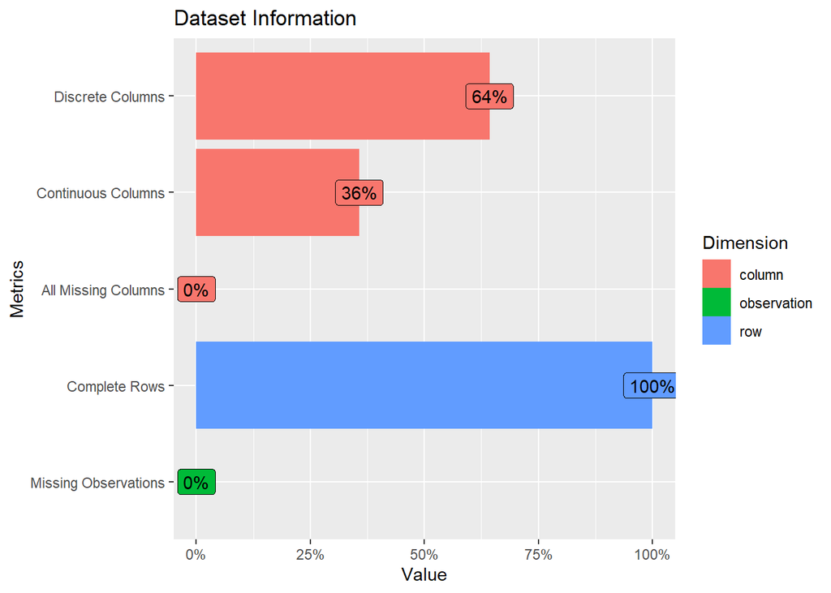

```r
plot_intro(dataset1,title="Dataset Information")
```

### Table

```r
introduce(dataset1)
```

| rows | columns | discrete_columns | continuous_columns | all_missing_columns | total_missing_values | complete_rows | total_observations | memory_usage |
| --- | --- | --- | --- | --- | --- | --- | --- | --- |
| 303 | 14 | 9 | 5 | 0 | 0 | 303 | 4242 | 23976 |

**Observations**

- Based on the table and Bar plot, the dataset indicates zero missing values and columns
- The dataset has 303 instances and 14 attributes
- Based on new dataset has 9 discrete column and 5 continuous columns(looks good now)

#### Descriptive Basic Statistics

- Here we are going to analyse the statistical Summary of each attribute

```r
describeBy(dataset1)
```

|  | vars | n | mean | sd | median | trimmed | mad | min | max | range | skew | kurtosis | se |
| --- | --- | --- | --- | --- | --- | --- | --- | --- | --- | --- | --- | --- | --- |
| sex* | 1 | 303 | 1.683168 | 0.4660108 | 2.0 | 1.7283951 | 0.00000 | 1 | 2.0 | 1.0 | -0.7835174 | -1.39065743 | 0.02677162 |
| cp* | 2 | 303 | 1.966997 | 1.0320525 | 2.0 | 1.8641975 | 1.48260 | 1 | 4.0 | 3.0 | 0.4799436 | -1.20511726 | 0.05928987 |
| fbs* | 3 | 303 | 1.148515 | 0.3561979 | 1.0 | 1.0617284 | 0.00000 | 1 | 2.0 | 1.0 | 1.9670254 | 1.87541099 | 0.02046303 |
| restecg* | 4 | 303 | 1.528053 | 0.5258596 | 2.0 | 1.5185185 | 0.00000 | 1 | 3.0 | 2.0 | 0.1609167 | -1.37083448 | 0.03020984 |
| exng* | 5 | 303 | 1.326733 | 0.4697945 | 1.0 | 1.2839506 | 0.00000 | 1 | 2.0 | 1.0 | 0.7351959 | -1.46428695 | 0.02698899 |
| slp* | 6 | 303 | 2.399340 | 0.6162261 | 2.0 | 2.4609053 | 1.48260 | 1 | 3.0 | 2.0 | -0.5032939 | -0.65252214 | 0.03540127 |
| caa* | 7 | 303 | 1.729373 | 1.0226064 | 1.0 | 1.5390947 | 0.00000 | 1 | 5.0 | 4.0 | 1.2974762 | 0.78065224 | 0.05874720 |
| thall* | 8 | 303 | 3.313531 | 0.6122765 | 3.0 | 3.3580247 | 0.00000 | 1 | 4.0 | 3.0 | -0.4720126 | 0.25171440 | 0.03517437 |
| output* | 9 | 303 | 1.544554 | 0.4988348 | 2.0 | 1.5555556 | 0.00000 | 1 | 2.0 | 1.0 | -0.1780446 | -1.97478493 | 0.02865731 |
| age | 10 | 303 | 54.366337 | 9.0821010 | 55.0 | 54.5432099 | 10.37820 | 29 | 77.0 | 48.0 | -0.2004632 | -0.56912374 | 0.52175307 |

[output cut: 4 more lines]

**Observations**

#### Correlation Plot Analysis

```r
## plot correlations
correlation_tab <- cor(dataset)
col <- colorRampPalette(c("#BB4444", "#EE9988", "#FFFFFF", "#77AADD", "#4477AA"))
#png(file="corr2.png",res=150,width=900,height=700)
corrplot(correlation_tab, method = "color", shade.col = NA, tl.col = "black", tl.srt = 45,tl.cex =4,cl.cex=4,col = col(200), addCoef.col = "black", order = "AOE",number.cex = 3)
```

[figure not shown]

**Observations**

Positive correlations are displayed in blue and negative correlations in red color. Color intensities are proportional to the correlation coefficients

- fbs and chl are least correlated with output
- There is strong positive correlation of output with cp,thalachh,slp and negative correlation with exng,oldpeak,caa,thall and sex.
- Age and Thalachh are negatively correlated
- exang and cp are also negatively correlated
- slp is correlated with oldpeak and thalachh

#### Output Distribution

To see if the dataset is balanced or not

- 0= less chance of heart attack,
- 1= more chance of heart attack

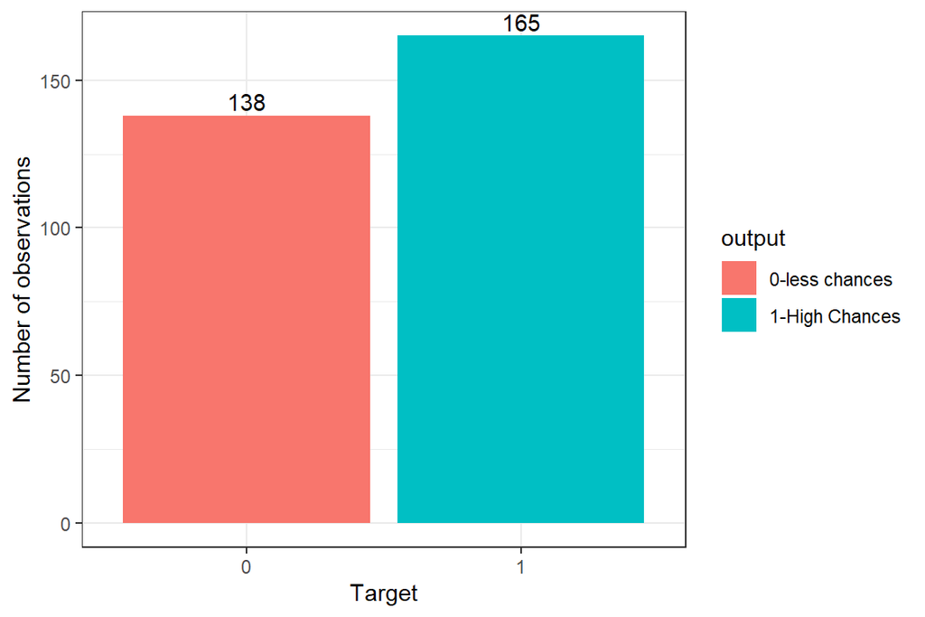

```r
df_output <- dataset1 %>%
  group_by(output) %>%
  summarise(freq= n()) %>%
  mutate(percentage= freq/sum(freq)*100)

output_bar <- ggplot(dataset1, aes(x=output, fill=output)) +
  geom_bar( ) +geom_text(stat='count',aes(label=..count..),vjust=-0.30)+
  labs( x = 'Target', y = 'Number of observations')+scale_fill_discrete(labels=c('0-less chances', '1-High Chances'))+theme_bw()

output_bar
```

**Observation**

- According to the dataset almost 54% of people have more chance of heart attack while 46% has a less chance of heart attack

#### Categorical feature Analysis

- Analysis with respect to output distribution

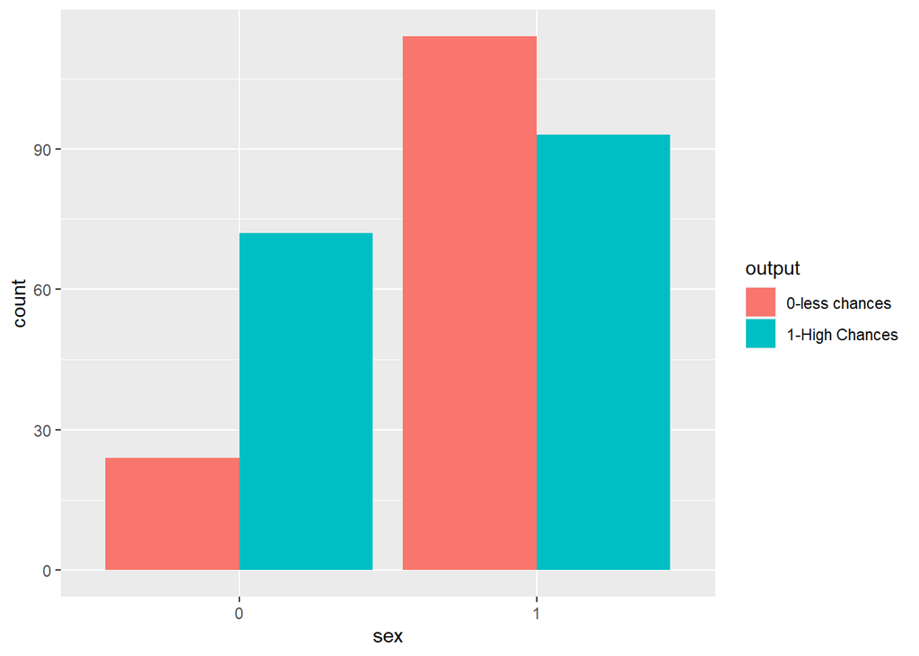

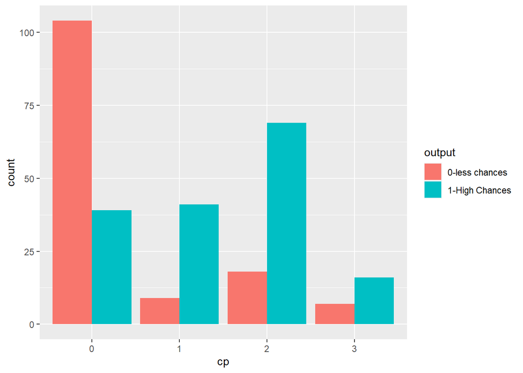

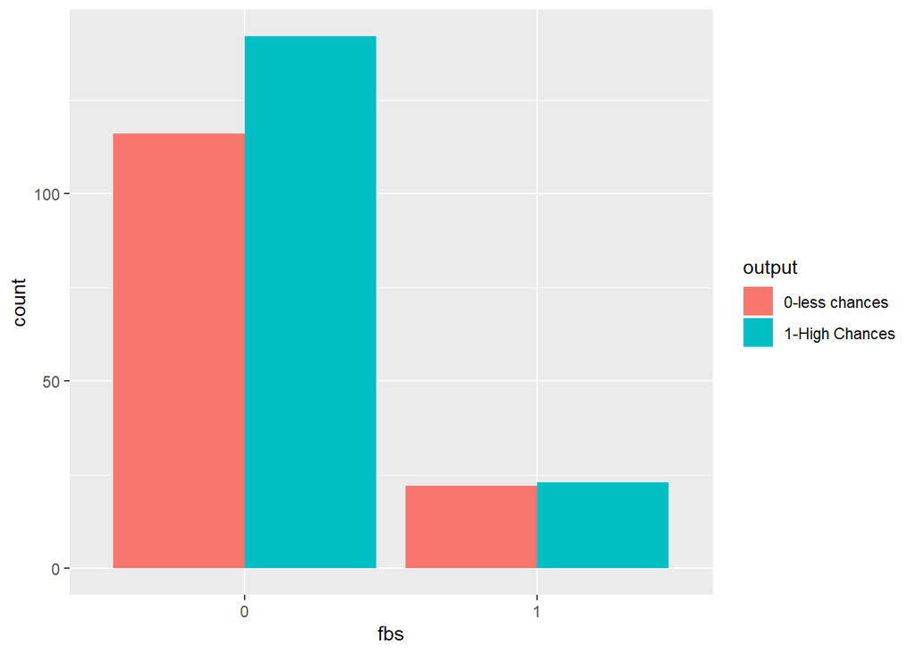

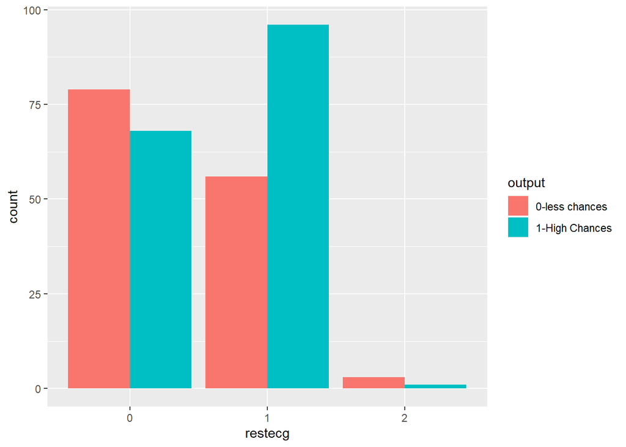

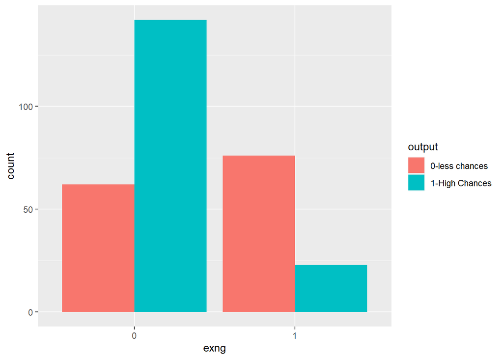

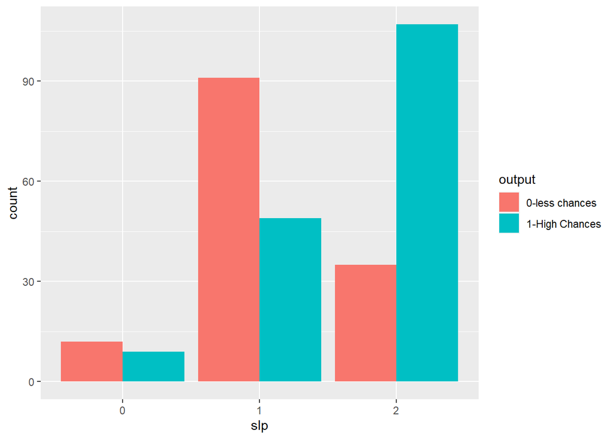

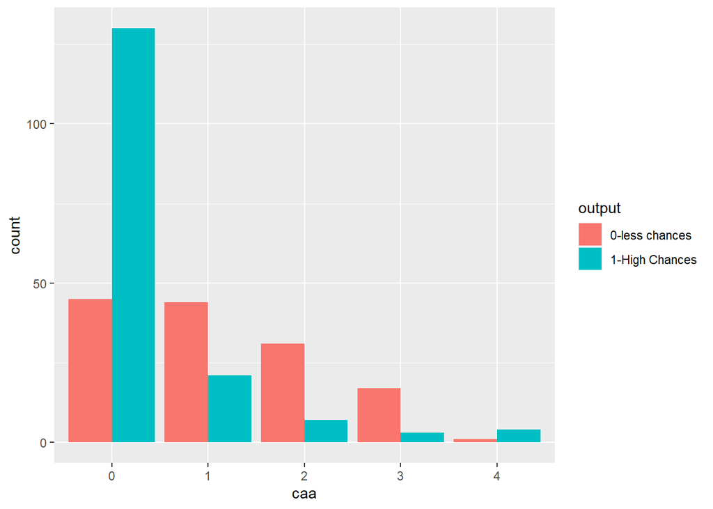

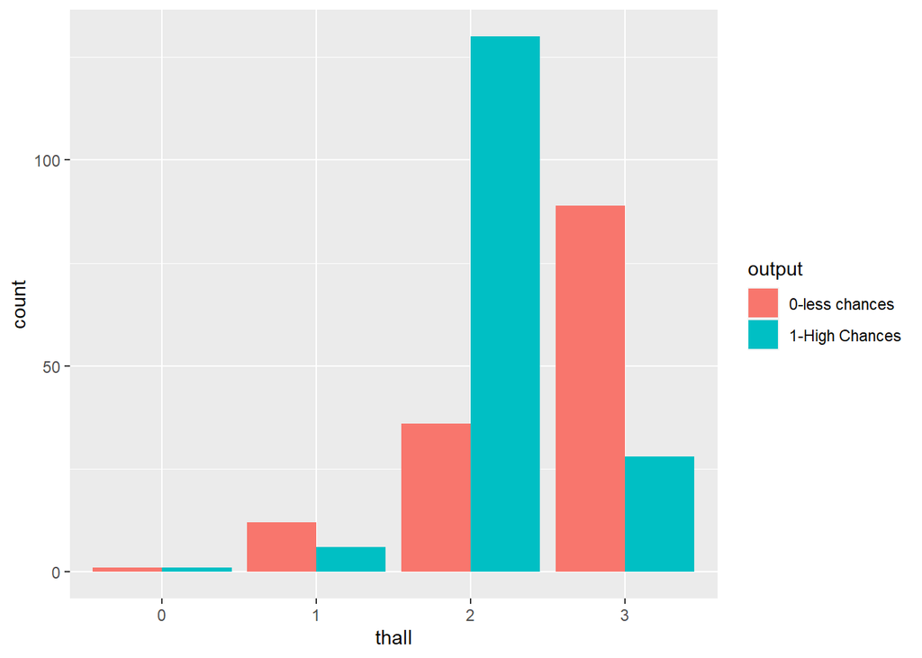

```r
#select the categorical variable
par(mfrow=c(2,2))
categorical_var<- list("sex","cp","fbs","restecg","exng","slp","caa",
        "thall")
for(i in categorical_var){
  plot<- ggplot(dataset1,aes_string(x=i,fill=dataset1$output))+geom_bar(position = position_dodge()) + scale_fill_discrete(name="output",labels=c('0-less chances', '1-High Chances'))
  print(plot)
}
```

**Observations**

#### Numerical feature analysis

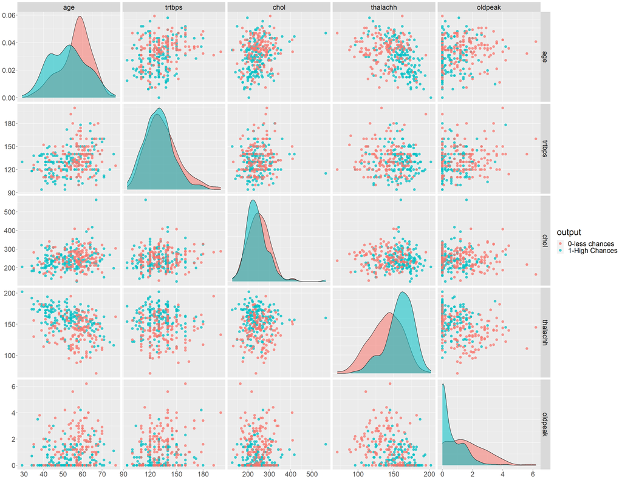

```r
## select the numerical features
## plot a pairplot
plt <- ggpairs(numeric_var,columns=1:5,ggplot2::aes(alpha=0.75,color=dataset1$output),legend=2,upper = list(continuous = wrap("points",alpha = 0.75,size=2.8)),
              lower = list(continuous = wrap("points",alpha = 0.75,size=2.8)))+ theme(text=element_text(size=22))+scale_colour_discrete(name="output",labels=c('0-less chances', '1-High Chances'))
plt
```

### 3.Handling Outliers:

There are several methods on how to detect outliers in a dataset such as using Box plots,Scatter plot,Z score etc.Therefore,i have used boxplot analysis on numerical variables to detect the outliers

#### Boxplot Analysis

- A box plot is a graphical method to summarize a data set by visualizing the minimum value, 25th percentile, median, 75th percentile, the maximum value, and potential outliers(Denise C, 2015).

### Boxplot

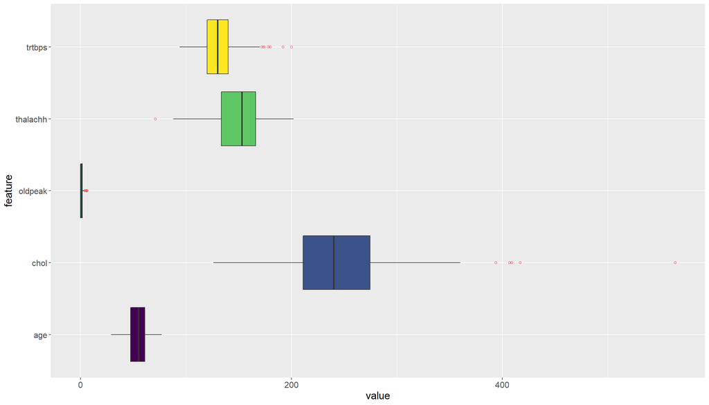

```r
#define the data
#classify the numerical variables into feature and value columns
data <- numeric_var %>%
  gather(key="feature", value="value") %>%
  mutate(feature = gsub("\\.", " ",feature))
data %>%
  mutate(text=fct_reorder(feature, value))%>%
  ggplot(aes(x=feature, y=value, fill=feature))+
     geom_boxplot(outlier.colour = "red",outlier.shape = 1.5)+
     scale_fill_viridis(discrete=TRUE)+theme(legend.position="false",
     text=element_text(size=15)) +coord_flip()
```

### Table

```r
head(data)
```

|  | feature | value |
| --- | --- | --- |
| 1 | age | 63 |
| 2 | age | 37 |
| 3 | age | 41 |
| 4 | age | 56 |
| 5 | age | 57 |
| 6 | age | 57 |

**Observations**

- In trtbps,thalachh and chol,features contains outliers unlike age which are indicated by small red circle ,These outliers might affect the analysis and prediction accuracy.

#### Remove the Outliers

- Before we remove outliers, you must first decide on what you consider to be an outlier. There are several ways to do so: Using the interquartile range.
- The interquartile range (IQR) is the difference between the 75th percentile (Q3) and the 25th percentile (Q1) in a dataset.

```r
# create a dataframe from numerical variables and exclude age
df_outliers<-as.data.frame(dataset1 %>%
                  select("trtbps","thalachh","chol","oldpeak"))
```

```r
outliers <- function(x) {
 #IQR
  Q1 <- quantile(x, probs=.25)
  Q3 <- quantile(x, probs=.75)
  iqr = Q3-Q1

 #Upper Range
 upper_limit = Q3 + (iqr*1.5)
 #Lower Range Eliminating Outliers
 lower_limit = Q1 - (iqr*1.5)

 x > upper_limit | x < lower_limit
}
# remove the outliers
remove_outliers <- function(df_outliers, cols = names(df_outliers)) {
  for (col in cols) {
    df_outliers<- df_outliers[!outliers(df_outliers[[col]]),]
  }
  df_outliers
}
# we have removed the outliers from the selected features
# create new dataset without outliers
dataset2<-remove_outliers(dataset1,c("trtbps","oldpeak" ,"thalachh", "chol"))
```

```r
#check the dimesions of the new dataset
dim(dataset2)
```

```
[1] 284  14
```

**Observation**

- Compared to dataset1 the dimensions have decreased, which indicates that rows with outliers have been removed from the dataset1.

##### Boxplot Without Outliers

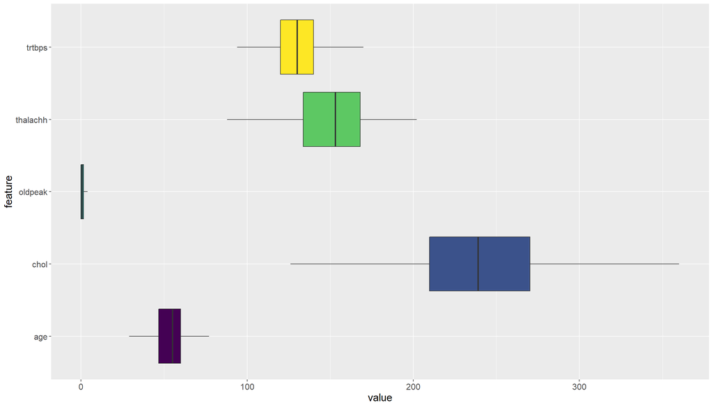

```r
#define the data
#classify the numerical variables into feature and value columns
numeric_feature <- dataset2%>%
  select("trtbps","oldpeak" ,"thalachh", "chol","age")
data <- numeric_feature %>%
  gather(key="feature", value="value") %>%
  mutate(feature = gsub("\\.", " ",feature))

data %>%
  mutate(text = fct_reorder(feature, value)) %>%
  ggplot( aes(x=feature, y=value, fill=feature)) +
  geom_boxplot(outlier.colour = "red",outlier.shape = 1.5) +
  scale_fill_viridis(discrete=TRUE) +
  theme(legend.position="false",text=element_text(size=15)
  ) +
  coord_flip()
```

#### 4.Feature Selection

- According to Michail.T(2018),Feature (or variable) selection is the process of identifying the minimal set of features with the highest predictive performance on the target variable of interest.
- There are several feature selection methods provided by the caret R package,and among are Searching for and removing redundant feature,Boruta,Ranking features by importance,RFE etc.
- In this dataset we are going to use automatic methods, using Recursive Feature Elimination(RFE).

### Predictors Results

```r
set.seed(100)
#create the subsets for sizes
subsets <- c(1:8,10,13)
# define the control using random forest selection
ctrl <- rfeControl(functions = rfFuncs,
                   method = "repeatedcv",
                   repeats = 5,
                   number = 10,
                   verbose = FALSE)

#run the RFE
results <- rfe(x=dataset2[, c(1:8,10:14)], y=dataset2$output,
                 sizes = subsets,
                 rfeControl = ctrl)

# Print the selected features
print(predictors(results))
```

```
[1] "caa"      "thall"    "cp"       "oldpeak"  "sex"      "thalachh" "exng"
[8] "age"
```

### Variable Importance

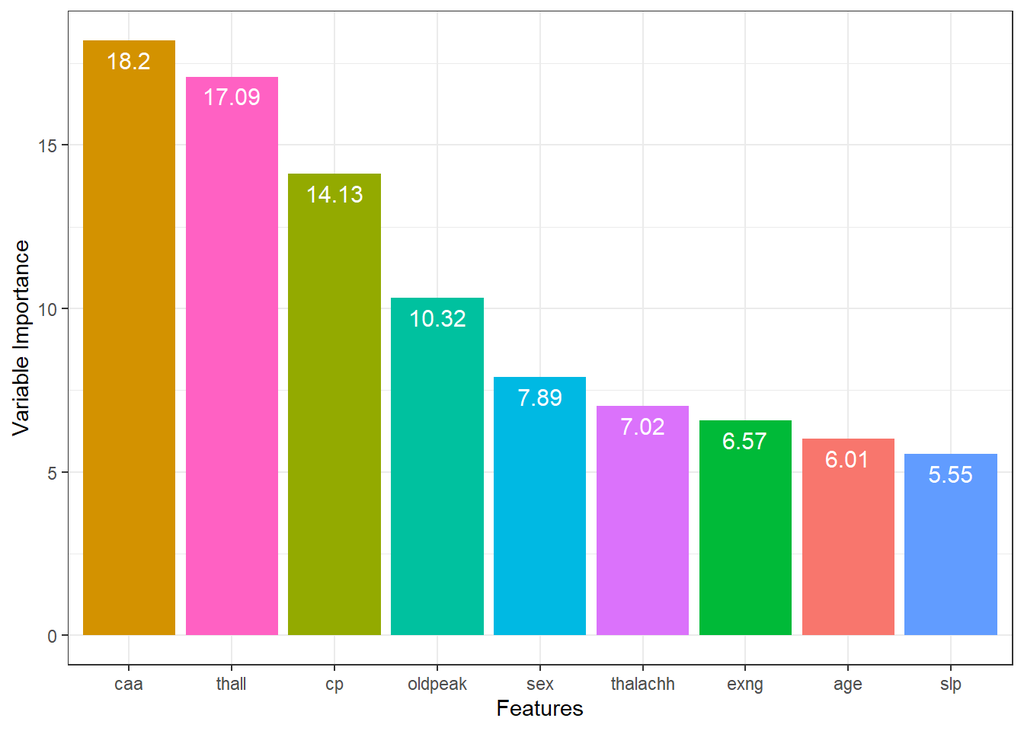

```r
set.seed(100)
varimp_data <- data.frame(feature = row.names(varImp(results))[1:9],
                          importance = varImp(results)[1:9, 1])

ggplot(data = varimp_data,
       aes(x = reorder(feature, -importance), y = importance, fill = feature)) +
  geom_bar(stat="identity") + labs(x = "Features", y = "Variable Importance") +
  geom_text(aes(label = round(importance, 2)), vjust=1.6, color="white", size=4) +
  theme_bw() + theme(legend.position = "none")
```

**Observations**

- Based on the RFE analysis only 8 features are selected , while fbs, and restecg are regarded as least important and they can affect the prediction model accuracy results.

```r
#drop the least columns from the dataset2
set.seed(100)
data1 <- dataset2 %>%
  select( "sex","cp","caa","thall","exng","slp","age","oldpeak","thalachh","output")
head(data1)
```

|  | sex | cp | caa | thall | exng | slp | age | oldpeak | thalachh | output |
| --- | --- | --- | --- | --- | --- | --- | --- | --- | --- | --- |
| 1 | 1 | 3 | 0 | 1 | 0 | 0 | 63 | 2.3 | 150 | 1 |
| 2 | 1 | 2 | 0 | 2 | 0 | 0 | 37 | 3.5 | 187 | 1 |
| 3 | 0 | 1 | 0 | 2 | 0 | 2 | 41 | 1.4 | 172 | 1 |
| 4 | 1 | 1 | 0 | 2 | 0 | 2 | 56 | 0.8 | 178 | 1 |
| 5 | 0 | 0 | 0 | 2 | 1 | 2 | 57 | 0.6 | 163 | 1 |
| 6 | 1 | 0 | 0 | 1 | 0 | 1 | 57 | 0.4 | 148 | 1 |

#### 6.Split the Dataset

```r
set.seed(100)
split = sample.split(data1$output, SplitRatio = 0.80)
train_set = subset(data1, split == TRUE)
test_set = subset(data1, split == FALSE)
```

```r
# Feature Scaling
set.seed(100)
train_set[c(7,8,9)]= scale(train_set[c(7,8,9)])
test_set[c(7,8,9)] = scale(test_set[c(7,8,9)])
head(test_set)
```

|  | sex | cp | caa | thall | exng | slp | age | oldpeak | thalachh | output |
| --- | --- | --- | --- | --- | --- | --- | --- | --- | --- | --- |
| 7 | 0 | 1 | 0 | 2 | 0 | 1 | 0.318867155 | 0.2274848 | 0.07750473 | 1 |
| 13 | 1 | 1 | 0 | 2 | 0 | 2 | -0.442977126 | -0.4208469 | 0.97098625 | 1 |
| 30 | 1 | 2 | 0 | 2 | 0 | 0 | -0.007637537 | 0.1348660 | 0.02786687 | 1 |
| 34 | 1 | 2 | 1 | 2 | 0 | 0 | 0.101197361 | -0.5134658 | 0.02786687 | 1 |
| 36 | 0 | 2 | 0 | 2 | 1 | 0 | -0.769481818 | 0.3201037 | 0.42496977 | 1 |
| 38 | 1 | 2 | 0 | 3 | 0 | 2 | 0.101197361 | 0.5053413 | 0.67315908 | 1 |

#### 7.Model Classification

#### Naive Bayes

```r
set.seed(100)
classifier = naiveBayes(x = train_set[-10],y = train_set$output)
y_pred = predict(classifier, newdata = test_set[-10])
cm = confusionMatrix(test_set[, 10], y_pred)
cm
```

```
Confusion Matrix and Statistics

          Reference
Prediction  0  1
         0 20  5
         1  2 30

               Accuracy : 0.8772
                 95% CI : (0.7632, 0.9492)
    No Information Rate : 0.614
    P-Value [Acc > NIR] : 1.096e-05

                  Kappa : 0.7473

 Mcnemar's Test P-Value : 0.4497

            Sensitivity : 0.9091
            Specificity : 0.8571
         Pos Pred Value : 0.8000
         Neg Pred Value : 0.9375
             Prevalence : 0.3860
         Detection Rate : 0.3509
   Detection Prevalence : 0.4386
      Balanced Accuracy : 0.8831

       'Positive' Class : 0
```

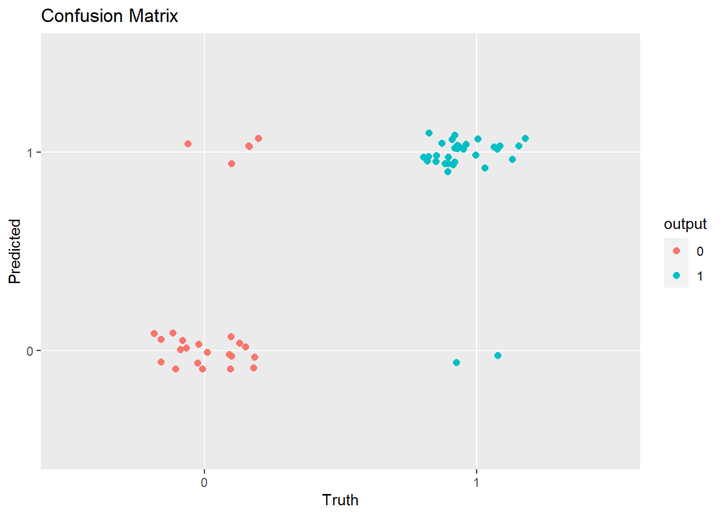

```r
set.seed(100)
naive_acc <- cm$overall["Accuracy"]
#plot confusion Matrix
test_set$pred <- y_pred
ggplot(test_set, aes(output, pred, color = output)) +
  geom_jitter(width = 0.2, height = 0.1, size=2) +
  labs(title="Confusion Matrix",
       y="Predicted",
       x="Truth")
```

#### Support Vector Machine(SVM)

```r
set.seed(100)
svm_model= svm(formula=output~.,
             data=train_set,
             type="C-classification",
             kernal="linear")
y_pred= predict(svm_model,newdata = test_set[-10])

cm= confusionMatrix(test_set[, 10], y_pred)
cm
```

```
Confusion Matrix and Statistics

          Reference
Prediction  0  1
         0 20  5
         1  4 28

               Accuracy : 0.8421
                 95% CI : (0.7213, 0.9252)
    No Information Rate : 0.5789
    P-Value [Acc > NIR] : 1.998e-05

                  Kappa : 0.678

 Mcnemar's Test P-Value : 1

            Sensitivity : 0.8333
            Specificity : 0.8485
         Pos Pred Value : 0.8000
         Neg Pred Value : 0.8750
             Prevalence : 0.4211
         Detection Rate : 0.3509
   Detection Prevalence : 0.4386
      Balanced Accuracy : 0.8409

       'Positive' Class : 0
```

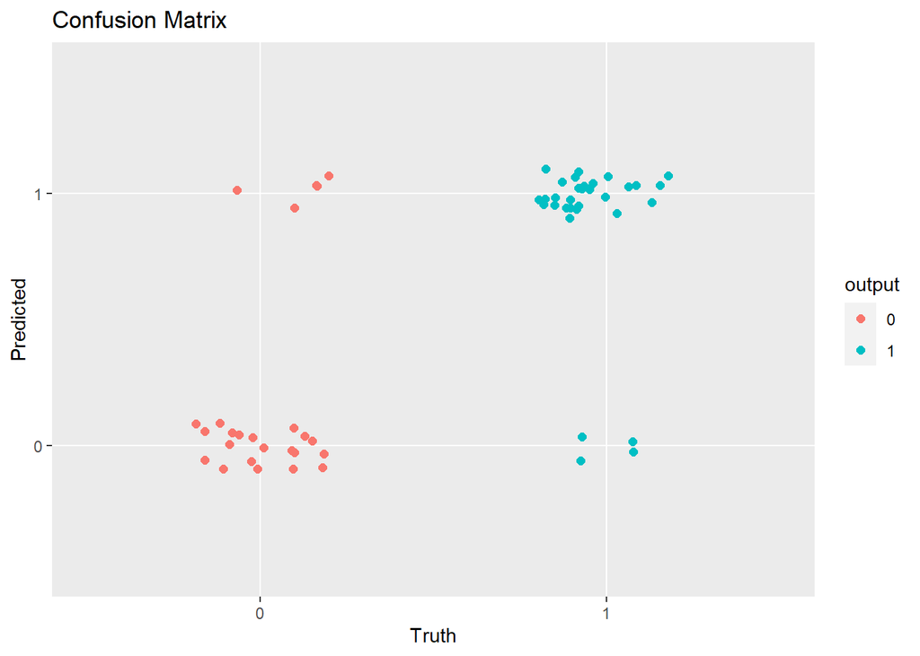

```r
set.seed(100)
svm_acc <- cm$overall["Accuracy"]
#plot confusion Matrix
test_set$pred <- y_pred
ggplot(test_set, aes(output, pred, color = output)) +
  geom_jitter(width = 0.2, height = 0.1, size=2) +
  labs(title="Confusion Matrix",
       y="Predicted",
       x="Truth")
```

#### Random Forest Model

```r
set.seed(100)
#Initial model
random_frst <- randomForest( output ~ .,
                             data=train_set)

y_pred <- predict(random_frst, test_set)

#plot confusion matrix
cm<-confusionMatrix(factor(y_pred),test_set$output)
cm
```

```
Confusion Matrix and Statistics

          Reference
Prediction  0  1
         0 18  3
         1  7 29

               Accuracy : 0.8246
                 95% CI : (0.7009, 0.9125)
    No Information Rate : 0.5614
    P-Value [Acc > NIR] : 2.515e-05

                  Kappa : 0.6374

 Mcnemar's Test P-Value : 0.3428

            Sensitivity : 0.7200
            Specificity : 0.9062
         Pos Pred Value : 0.8571
         Neg Pred Value : 0.8056
             Prevalence : 0.4386
         Detection Rate : 0.3158
   Detection Prevalence : 0.3684
      Balanced Accuracy : 0.8131

       'Positive' Class : 0
```

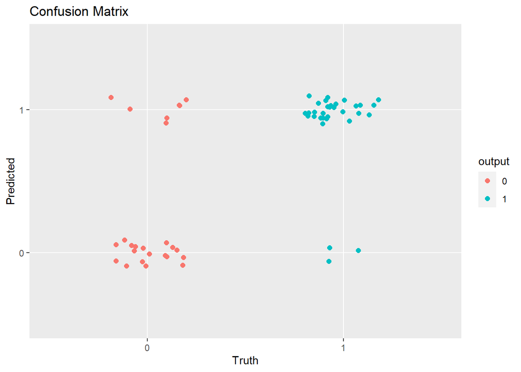

```r
set.seed(100)
random_acc <- cm$overall["Accuracy"]
#plot confusion Matrix
test_set$pred <- y_pred
ggplot(test_set, aes(output, pred, color = output)) +
  geom_jitter(width = 0.2, height = 0.1, size=2) +
  labs(title="Confusion Matrix",
       y="Predicted",
       x="Truth")
```

#### Logistic Regression

```r
#logistic regression model
set.seed(100)
logistic_reg = glm(formula = output ~ .,
                 family = binomial,
                 data = train_set)
prob_pred= predict(logistic_reg,type='response',newdata = test_set[-10])
y_pred = ifelse(prob_pred > 0.5, 1, 0)

#confusion matrix
cm = confusionMatrix(test_set[,10],factor(y_pred))
cm
```

```
Confusion Matrix and Statistics

          Reference
Prediction  0  1
         0 19  6
         1  2 30

               Accuracy : 0.8596
                 95% CI : (0.7421, 0.9374)
    No Information Rate : 0.6316
    P-Value [Acc > NIR] : 0.0001263

                  Kappa : 0.7099

 Mcnemar's Test P-Value : 0.2888444

            Sensitivity : 0.9048
            Specificity : 0.8333
         Pos Pred Value : 0.7600
         Neg Pred Value : 0.9375
             Prevalence : 0.3684
         Detection Rate : 0.3333
   Detection Prevalence : 0.4386
      Balanced Accuracy : 0.8690

       'Positive' Class : 0
```

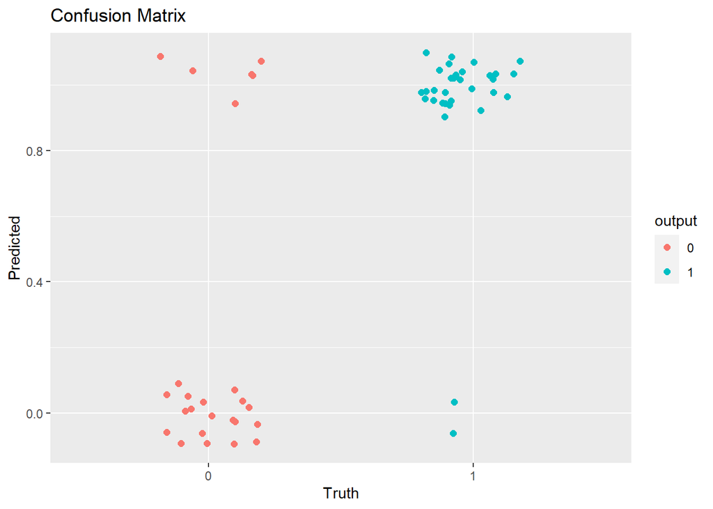

```r
set.seed(100)
glm_acc <- cm$overall["Accuracy"]
#plot confusion Matrix
test_set$pred <- y_pred
ggplot(test_set, aes(output, pred, color = output)) +
  geom_jitter(width = 0.2, height = 0.1, size=2) +
  labs(title="Confusion Matrix",
       y="Predicted",
       x="Truth")
```

#### K Nearest Neighbor

```r
set.seed(100)
#initial model
y_pred<-knn(train=train_set[,1:10],test = test_set[,1:10],cl=train_set$output,k=5)

#confusion matrix
cm=confusionMatrix(test_set$output,y_pred)
cm
```

```
Confusion Matrix and Statistics

          Reference
Prediction  0  1
         0 21  4
         1  1 31

               Accuracy : 0.9123
                 95% CI : (0.807, 0.9709)
    No Information Rate : 0.614
    P-Value [Acc > NIR] : 4.061e-07

                  Kappa : 0.8195

 Mcnemar's Test P-Value : 0.3711

            Sensitivity : 0.9545
            Specificity : 0.8857
         Pos Pred Value : 0.8400
         Neg Pred Value : 0.9688
             Prevalence : 0.3860
         Detection Rate : 0.3684
   Detection Prevalence : 0.4386
      Balanced Accuracy : 0.9201

       'Positive' Class : 0
```

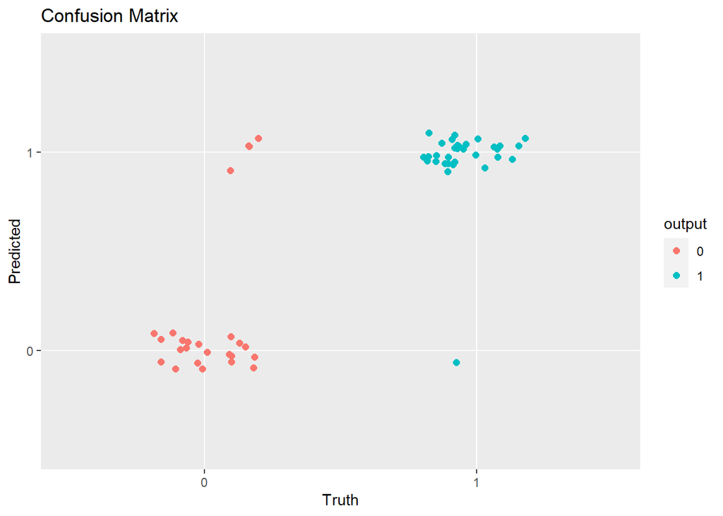

```r
set.seed(100)
Knn_acc <- cm$overall["Accuracy"]
#plot confusion Matrix
test_set$pred <- y_pred
ggplot(test_set, aes(output, pred, color = output)) +
  geom_jitter(width = 0.2, height = 0.1, size=2) +
  labs(title="Confusion Matrix",
       y="Predicted",
       x="Truth")
```

#### 8.Model Comparison

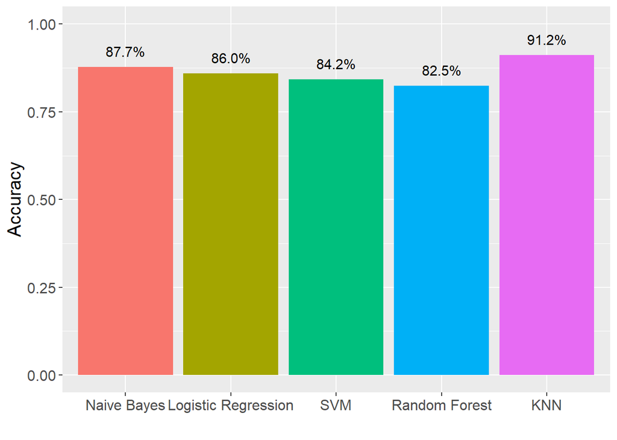

```r
set.seed(100)
# create a dataframe for models accuracy
model_names <- c("Naive Bayes", "Logistic Regression","SVM","Random Forest",'KNN')
# extract accuracy for various models
acc<- c(naive_acc, glm_acc, svm_acc,random_acc,Knn_acc)
df_acc <- data.frame(model_names, acc)
df_acc$model_names <- factor(df_acc$model_names,levels = df_acc$model_names)

ggplot( mapping = aes(x=df_acc$model_names)) +
    geom_bar(aes(y = ..acc.., fill = df_acc$model_names),width = 0.9,show.legend = FALSE) + geom_text(aes( y = ..acc.., label = scales::percent(..acc..)),size=4, stat = "count", vjust = -1)+ ylim(0, 1)+labs(y = "Accuracy", x="")+
    theme(text = element_text(size = 15))
```